# Classification - Part I

Yujia Pan (yujiap@umich.edu)

Big Data Summer Institute 2018

University of Michigan

# Statistical learning

We observe a **response** $Y$ and $p$ different predictors (or **features**), $X_1, X_2, \ldots, X_p$.

We assume that there is some relationship between $Y$ and $X = (X_1, X_2, \cdots, X_p)$: $$Y = f(X) + \epsilon$$

The function $f$ is unknown, so we must estimate it from data.

**Statistical learning** refers to a set of methods for estimating $f$ from data.

# Why estimate $f$?

1. **Prediction**
   - If $\widehat{f}$ is an accurate estimate of $f$, then we can make predictions: $$\widehat{Y} = \widehat{f}(X)$$
   - Care about accuracy of predictions made by $\widehat{f}$, not necessarily its functional form
   - e.g. predicting whether a patient's tumor is cancerous or benign from their gene expression
   - e.g. predicting a patient's insulin level after taking a diabetes drug
2. **Inference**
   - Understanding the way that $Y$ is affected as $X_1, \ldots, X_n$ change
   - Care about functional form of $\widehat{f}$, not necessarily to make predictions

# What do we mean by accurate prediction?

- $\widehat{f}$ is not a perfect estimate for $f$, so $\widehat{Y}$ is not a perfect estimate for $Y$!
- Accuracy of $\widehat{Y}$ for $Y$:
  - reducible error
  - irreducible error ($\epsilon$)
    - unmeasured variables predictive of $Y$
    - measurement error
- We can decrease reducible error, but cannot decrease irreducible error, no matter how well we estimate $f$
- Accurate prediction = minimizing reducible error

# Our focus: classification

We will focus on prediction when the response $Y$ is a **categorical** variable denoting **class membership**.

- e.g. {"cancerous","benign"}, perhaps coded as $\{-1, 1\}$

This statistical learning task is called **classification**.

- Many different methods for estimating $f$ in this context

*Note: A particular estimate of $f$ is called a **classifier**, but this term is also used to refer to the estimation method*

# How do we estimate $f$?

- We will assume we have observed $n$ data points: $$\{ (\mathbf{x_1}, y_1) , (\mathbf{x_2}, y_2) , \ldots, (\mathbf{x_n}, y_n)\}$$ where $\mathbf{x_i} \in \mathbb{R}^p$ and $y_i \in \{ -1, 1\}$.
- This is called the **training data**, since we will use it to "train" our classifier.
- That is, we want to use the training data to estimate $f$ so that $Y \approx \widehat{f}(X)$ for any observation $(X, Y)$
  - parametric methods
  - nonparametric methods

## Parametric methods

1. Assume the shape or functional form of $f$. $$\text{e.g.}~~~f(X) = \beta_0 + \beta_1 X_1 + \ldots +\beta_p X_p~~~\text{($f$ linear)}$$
1. "Training" = using the training data to estimate the **parameters** $\beta_0, \beta_1, \ldots, \beta_p$.

Problem of estimating $f$ is reduced to estimating a set of parameters.

## Nonparametric methods

- Do not assume make explicit assumptions about the shape of $f$
  - In what ways is this an advantage?
  - In what ways is this a disadvantage?

## Nonparametric methods

- Do not assume make explicit assumptions about the shape of $f$
  - In what ways is this an advantage?
    - Can be more flexible
    - Parametric assumptions could be wrong!
  - In what ways is this a disadvantage?
    - Typically need more data to estimate $f$ accurately

# How to assess accuracy?

How do we measure how well a classifier's predictions match the observed data?

- Doesn't make sense to use **training error rate**, since we want to know if $f$ is accurate on previously unseen test observations
- Solution: apply classifier to a **test set**, a set of observations not used to train the classifier. $$\text{test error rate}= \frac{1}{\widetilde{n}}\sum_{i=1}^\widetilde{n} I(\widetilde{y}_i \neq \widehat{y}_i) = \frac{\text{# incorrect predictions's in test set}}{\text{# observations in test set}}$$
- If we have a large number of observations, we can split our dataset in two, thus creating a training set and test set
- What if no test set is available, or we don't have a large number of observations?
  - Solution: crossvalidation

# Classification methods

- Parametric
  - linear: LDA, Logistic regression
  - nonlinear: QDA
- Nonparametric
  - kNN
  - Random Forests

# Our dataset

$$ Y_i = \begin{cases} 1 ~~~\text{ if patient $i$ has heart disease} \\ 0 ~~~\text{ if patient $i$ has no heart disease} \end{cases} $$

Documentation: https://archive.ics.uci.edu/ml/datasets/Heart+Disease

```r
if (!file.exists("processed.cleveland.data")) {
  download.file(url = "http://archive.ics.uci.edu/ml/machine-learning-databases/heart-disease/processed.cleveland.data", destfile = "processed.cleveland.data")
  }
require(tools)
```

```r
heart.data <- read.csv("processed.cleveland.data", header = FALSE)
names(heart.data) <- c("age", "sex", "cp", "trestbps", "chol", "fbs", "restecg", "thalach", "exang", "oldpeak", "slope", "ca", "thal", "num")
X = heart.data[, c("chol", "thalach")]
Y = heart.data[, "num"]

# rename features
colnames(X) = c("chol", "maxHR")

# recode Y into disease (1) & no disease (0)
Y = ifelse(Y==0, 0, 1)

# randomly split into training and test sets
n = nrow(X)
train.ix = sample(1:n, n/2)

Xtrain = X[train.ix,]
Ytrain = Y[train.ix]
Xtest = X[-train.ix,]
Ytest = Y[-train.ix]

head(Xtest)
#dim(Xtrain)
#dim(Xtest)
#table(Ytrain)
#table(Ytest)
```

|  | chol | maxHR |
| --- | --- | --- |
| 1 | 233 | 150 |
| 7 | 268 | 160 |
| 9 | 254 | 147 |
| 11 | 192 | 148 |
| 12 | 294 | 153 |
| 13 | 256 | 142 |

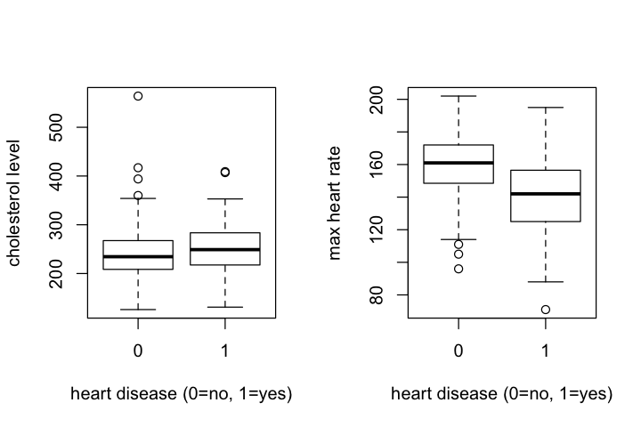

```r
options(repr.plot.width=6, repr.plot.height=4)
par(mfrow = c(1,2))
boxplot(X$chol ~ Y, xlab="heart disease (0=no, 1=yes)",
       ylab="cholesterol level")
boxplot(X$maxHR ~ Y, xlab="heart disease (0=no, 1=yes)",
       ylab="max heart rate")
```

# An optimal classifier exists

- The expected test error rate, $E[I(\widetilde{y} \neq \widehat{y})]$, is minimized by assigning each observation to the most likely class, given the values on the predictor variables.
- Rephrased: For each a test observation with predictor vector $\widetilde{x}$, the optimal classifier calculates $$P(Y=-1 | X=\widetilde{x}), P(Y=1 | X=\widetilde{x})$$ and predict the class with the larger conditional probability.
- This is called the **Bayes classifier**, which achieves the lowest possible test error rate.

# What's the catch?

- We don't know the conditional distribution of $Y$ given $X$, so we can't theoretically compute $P(Y=y|X=x)$!
- We can try to estimate the conditional distribution of $Y$ given $X$ and then classify a given observation to the class with highest *estimated* probability.

# $k$-nearest neighbors (kNN)

- Given $k$ and a test observation $X = \widetilde{x}$
  - Identify the $k$ points the training data closest to $\widetilde{x}$ (call this set of points $\mathcal{N}_k$)
  - Estimate the conditional probability for class $j$: $$P(Y=j | X=\widetilde{x}) = \frac 1k \sum_{i \in \mathcal{N}_k} I(y_i=j)$$
  - Classify the observation to the class with the largest probability.

## kNN in R

```r
# install.packages("class")
library(class)
class = knn(train = Xtrain, test = Xtest, cl = Ytrain, k = 20)

# calculating test accuracy rate
mean(class==Ytest)
```

0.618421052631579

## How to choose $k$?

- $k$ is called a **tuning parameter** . The process of finding a "good" $k$ is called tuning, and it is generally accomplished via a scheme called **cross-validation**.
- Will be discussed later! For now, observe that this choice has a big impact on the test accuracy rate:

```r
class = knn(train = Xtrain, test = Xtest, cl = Ytrain, k = 6)
mean(class==Ytest)
# note that ties are broken at random, so running this code
# multiple times will give different results
```

0.644736842105263

# Logistic Regression

For simplicity, suppose we're trying to predict heart disease ($Y \in \{0,1\}$) using just one feature, max heart rate ($X \in \mathbb{R}_+$).

- Instead of directly modeling the response $Y$, we could model the *probability* that $Y=1$ given $X$: $$p(X) = f(X) + \epsilon ~~~\text{where}~~~p(X)=P(Y = 1 | X)$$
- If $\widehat{p}(X) > 0.5$, classify $X$ to "heart disease", otherwise to "no heart disease"
- Probabilities are continuous...can we use linear regression?

$$p(X) = \beta_0 + \beta_1 X$$

$$\text{What's wrong with this?}$$

## What's wrong with using linear regression?

```r
Ytrain = ifelse(Ytrain==1, 1, 0)        # recode response from -1,1 to 0,1 (probabilities!)
Ytest = ifelse(Ytest==1, 1, 0)

train = data.frame(Xtrain, Ytrain)      # assemble dataframes
test = data.frame(Xtest, Ytest)
```

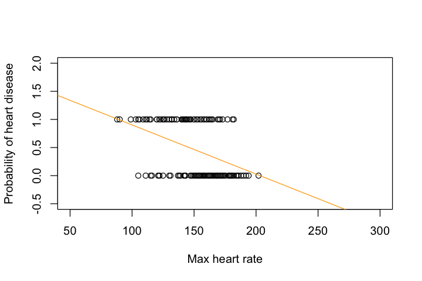

```r
fit = lm(Ytrain ~ maxHR, data = train)
preds = predict(fit, newdata = test)

plot(Xtest$maxHR, Ytest, xlim=c(50, 300) , ylim=c(-0.5, 2),
     xlab="Max heart rate", ylab="Probability of heart disease")
abline(fit, col="orange")
```

- This generally happens, unless the range of $X$ is limited
- To ensure that $p(X)$ always lies in $[0,1]$, model it using a special function whose range is $[0,1]$

$$p(X) = \frac{e^{\beta_0 + \beta_1 X}}{1 + e^{\beta_0 + \beta_1 X}}$$

- This is called the **logistic function**.

[figure not shown]

(Figure: http://learning.cis.upenn.edu/)

## Fitting the logistic regression classifier

- After some algebra: $$\frac{p(X)}{1-p(X)} = e^{\beta_0 + \beta_1 X}$$
- Take log of both sides: $$\log \left(\frac{p(X)}{1-p(X)}\right) = \beta_0 + \beta_1 X$$
- The left hand side is called the **log-odds (or logit)**. It's linear in X!
- Parameters are estimated via a technique called **maximum likelihood**
- To make predictions, we calculate $$\widehat{p}(X) = \frac{e^{\widehat{\beta}_0 + \widehat{\beta}_1 X}}{1 + e^{\widehat{\beta}_0 + \widehat{\beta}_1 X}}$$ for a given $X$ and classify based on whether $\widehat{p}(X)>0.5$.

## Logistic regression in R

```r
fit = glm(Ytrain ~ maxHR ,family=binomial(link='logit'), data=train)
preds = predict(fit, newdata = Xtest)
preds = ifelse(preds>=0.5, 1, 0)
mean(preds==Ytest)
```

0.671052631578947

# So far

- **kNN**: approximation to the Bayes classifier
- **Logistic regression**: use the logistic function to model $P(Y=j |X)$, instead of $Y$, as a linear function of $X$
- Our next classifier seeks to model $P(Y=j |X)$, just like logistic regression, but it does this slightly differently.

# Linear Discriminant Analysis (LDA)

## General idea

- Model the distribution of the predictors given the response: $$P(X = x | Y = j)$$
- Use Bayes' theorem to flip these around and get an expression for: $$P(Y = j | X = x)$$
- Make some parametric assumptions (normality, equal feature variances between classes)
- Estimate parameters
- Plug parameter estimates into the expression for $P(Y=j | X = x)$ and use this to make predictions.

## LDA when $p=1$

For simplicity, suppose we're trying to predict heart disease ($Y \in \{0,1\}$) using just one feature, max heart rate ($X \in \mathbb{R}_+$).

1. Recall **Bayes' rule**:

$$P(Y=j|X) = \frac{P(X, Y=j)}{P(X)} = \frac{P(X|Y=j)P(Y=j)}{P(X|Y=0)P(Y=0) + P(X|Y=1)P(Y=1)}$$

1. Change notation: $$P(Y=j|X) = \frac{f_j(x)\pi_j}{f_0(x)\pi_0 + f_1(x)\pi_1}$$
   - $\pi_j$: **prior** probability that a randomly given observation comes from class $j$
   - $f_j(x) := P(X=x|Y=j)$: the density function of $X$ for an observation in class $j$
   - $f_j(x)$ large $\leftrightsquigarrow$ high probability that an observtion in class $j$ has $X \approx x$
1. Assume $f_j(x)$ is a $N(\mu_j, \sigma_j^2)$ **normal density** for each $j$: $$f_j(x) = \frac{1}{\sqrt{2 \pi} \sigma_j} e^{ -\frac{1}{2\sigma_j^2} (x-\mu_j)^2}$$
   - If a person has heart disease ($Y=1$), then their max heart rate follows $N(\mu_1, \sigma_1^2)$
   - If a person does not have heart disease ($Y=0$), then their max heart rate follows $N(\mu_0, \sigma_0^2)$
2. Assume **equal feature variances** between classes: $\sigma_0 = \sigma_1$
1. Use our assumptions to simplify expression for $P(Y=j|X)$:

$$P(Y=j|X) = \frac{f_j(x)\pi_j}{f_0(x)\pi_0 + f_1(x)\pi_1}$$

$$P(Y=j|X) = \frac{\frac{1}{\sqrt{2 \pi} \sigma} e^{ -\frac{1}{2\sigma^2} (x-\mu_j)^2}\pi_j}{\frac{1}{\sqrt{2 \pi} \sigma} e^{ -\frac{1}{2\sigma^2} (x-\mu_0)^2}\pi_0 + \frac{1}{\sqrt{2 \pi} \sigma} e^{ -\frac{1}{2\sigma^2} (x-\mu_1)^2}\pi_1}$$

1. Estimate parameters $\mu_0, \mu_1, \sigma^2, \pi_1, \pi_2$.
2. Plug parameter estimates into our expression for $P(Y=j|X)$.
3. Make predictions: classify observation to the class for which the plug-in estimate of $P(Y=j|X)$ is largest.

## Why is it called linear discriminant analysis?

If we take log of $P(Y=j|X)$ and simplify, we see that an equivalent prediction rule is to classify an observation to the class for which

$$\delta_j(x) = x \cdot \frac{\mu_j}{\sigma^2} - \frac{\mu_j^2}{2\sigma^2} + \log(\pi_j) $$ is largest. This is called the **discriminant** function.

## LDA when $p>1$

Before we assumed we only had one feature, $$X=\texttt{maxHR}.$$

What if we have $p>1$ features? For instance,

$$X = (\texttt{maxHR}, \texttt{chol})^\top$$

Everything is largely the same!

- Still try to model $$P(Y=j|X = \mathbf{x}) = \frac{f_j(\mathbf{x})\pi_j}{f_0(\mathbf{x})\pi_0 + f_1(\mathbf{x})\pi_1}$$
- Still assume $f_j(\mathbf{x})$ is a normal density
- Still assume equal feature variances between classes
- Still classify an observation to the class giving the largest value of $P(Y=j|X=\mathbf{x})$

But since $X$ is now a $p$-dimensional vector, we need a higher dimensional generalization of the normal density and estimates for its parameters.

- The analogue of the $N(\mu, \sigma^2)$ density in $p$-dimensions is the **multivariate normal $\mathcal{N}_p(\mu, \Sigma)$** density: $$f(x) = \frac{1}{(2\pi)^{p/2}~|\Sigma|^{1/2}} \exp \left( -\frac 12 (x-\mu)^\top \Sigma^{-1} (x-\mu) \right)$$
  - $\mu_j = E(X)$ is the mean of $X$, a $p$-dimensional vector
  - $\Sigma = cov(X)$ is the $p \times p$ covariance matrix of $X$
- The estimates for $\mu, \Sigma$ are analogues of our familiar one-dimensional estimates.

## LDA in R

```r
# install.packages(MASS)
library(MASS)
fit = lda(Xtrain, Ytrain)
out = predict(fit, Xtest)
preds = out$class
mean(preds==Ytest)
```

0.697368421052632

# Quadratic Discriminant Analysis (QDA)

- What if we don't assume that all feature variances are equal?
- This gives rise to QDA, a nonlinear classifier
- You can fit this classifier in `R` using the function `qda` (from the `MASS` package)

# Decision boundaries

Every classifier $\widehat{f}$ defines a decision boundary:

- For **linear** classifiers, this is a hyperplane (e.g. a line in 2D, a plane in 3D)
- For **nonlinear** classifiers, this is a nonlinear "surface" (e.g. wiggly curve in 2D, "wavy plane" in 3D)
- If $X$ lies on one "side" of the boundary, the classifier classifies it to one class, and if $X$ lies on the other side, the classifier classifies it to the other class

Let's look at plots of decision boundaries for the classifiers we've looked at so far.

(This is not often done in practice, but is a nice way to visualize the behavior of classifiers.)

```r
# code from: http://michael.hahsler.net/SMU/EMIS7332/R/viz_classifier.html#k-nearest-neighbors-classifier

decisionplot <- function(model, data, class = NULL, predict_type = "class",
  resolution = 100, showgrid = TRUE, ...) {

  if(!is.null(class)) cl <- data[,class] else cl <- 1
  data <- data[,1:2]
  k <- length(unique(cl))

  plot(data, col = as.integer(cl)+1L, pch = as.integer(cl)+1L, ...)

  # make grid
  r <- sapply(data, range, na.rm = TRUE)
  xs <- seq(r[1,1], r[2,1], length.out = resolution)
  ys <- seq(r[1,2], r[2,2], length.out = resolution)
  g <- cbind(rep(xs, each=resolution), rep(ys, time = resolution))
  colnames(g) <- colnames(r)
  g <- as.data.frame(g)

  ### guess how to get class labels from predict
  ### (unfortunately not very consistent between models)
  p <- predict(model, g, type = predict_type)
  if(is.list(p)) p <- p$class
  p <- as.factor(p)

  if(showgrid) points(g, col = as.integer(p)+1L, pch = ".")

  z <- matrix(as.integer(p), nrow = resolution, byrow = TRUE)
  contour(xs, ys, z, add = TRUE, drawlabels = FALSE,
    lwd = 2, levels = (1:(k-1))+.5)

  invisible(z)
}
```

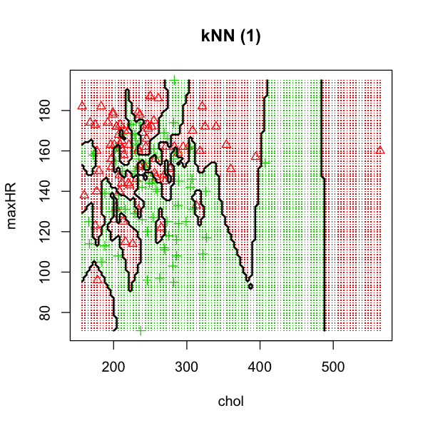

```r
options(repr.plot.width=5, repr.plot.height=5)
library(caret)
train$Ytrain = factor(Ytrain)

model = knn3(Ytrain ~ ., data=train, k = 1) # try changing k!
decisionplot(model, train, class = "Ytrain", main = "kNN (1)")
```

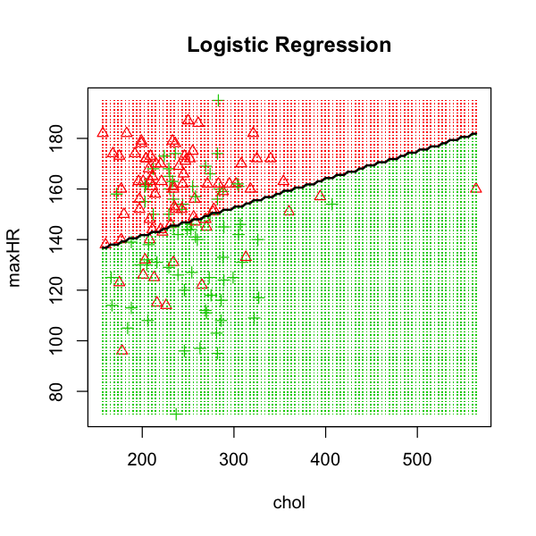

```r
lmodel <- glm(Ytrain ~., data = train, family=binomial(link='logit'))
class(lmodel) <- c("lr", class(lmodel))
predict.lr <- function(object, newdata, ...)
predict.glm(object, newdata, type = "response") > .5

decisionplot(lmodel, train, class = "Ytrain", main = "Logistic Regression")
```

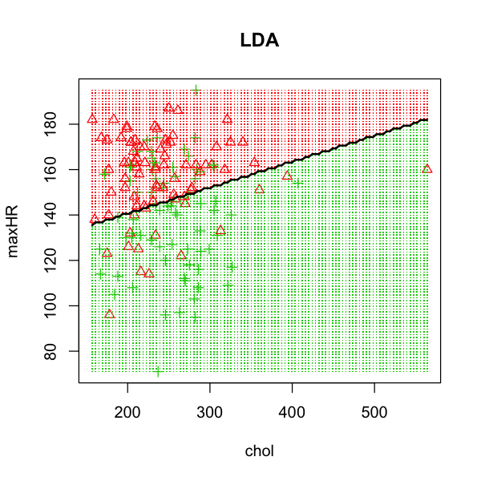

```r
model <- lda(Ytrain ~ ., data=train)
decisionplot(model, train, class = "Ytrain", main = "LDA")
```

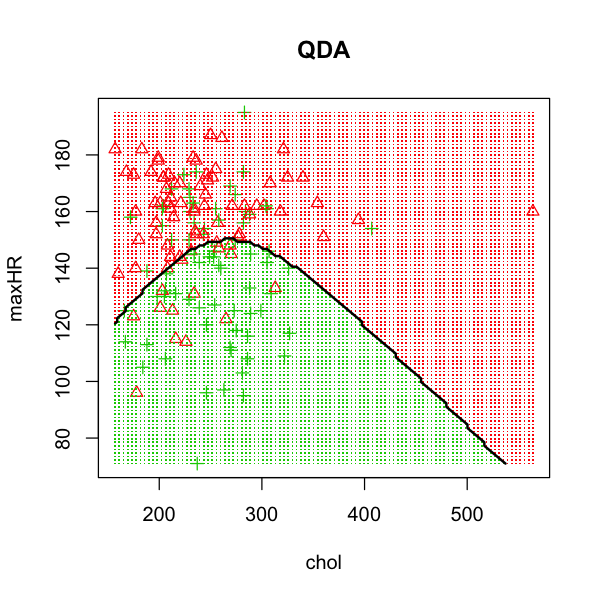

```r
model <- qda(Ytrain ~ ., data=train)
decisionplot(model, train, class = "Ytrain", main = "QDA")
```

# Random Forest

[figure not shown]

## Decision trees

- A **decision tree** is a series of splitting rules
- **Segment** the predictor space into several different regions
- Two flavors: regression trees and classification trees

### Regression trees: an example

Suppose we want to predict a **patient's cholesterol level** from two features, their **resting blood pressure** and **max heart rate**.

```r
X2 = heart.data[, c("trestbps", "thalach")]
Y2 = heart.data[,"chol"]

# rename features
colnames(X2) = c("restingBP", "maxHR")

# randomly split into training and test sets
n = nrow(X2)
train.ix = sample(1:n, n/2)

X2train = X2[train.ix,]
Y2train = Y2[train.ix]
X2test = X2[-train.ix,]
Y2test = Y2[-train.ix]

# assemble dataframes
train2 = data.frame(X2train, Y2train)
test2 = data.frame(X2test, Y2test)
```

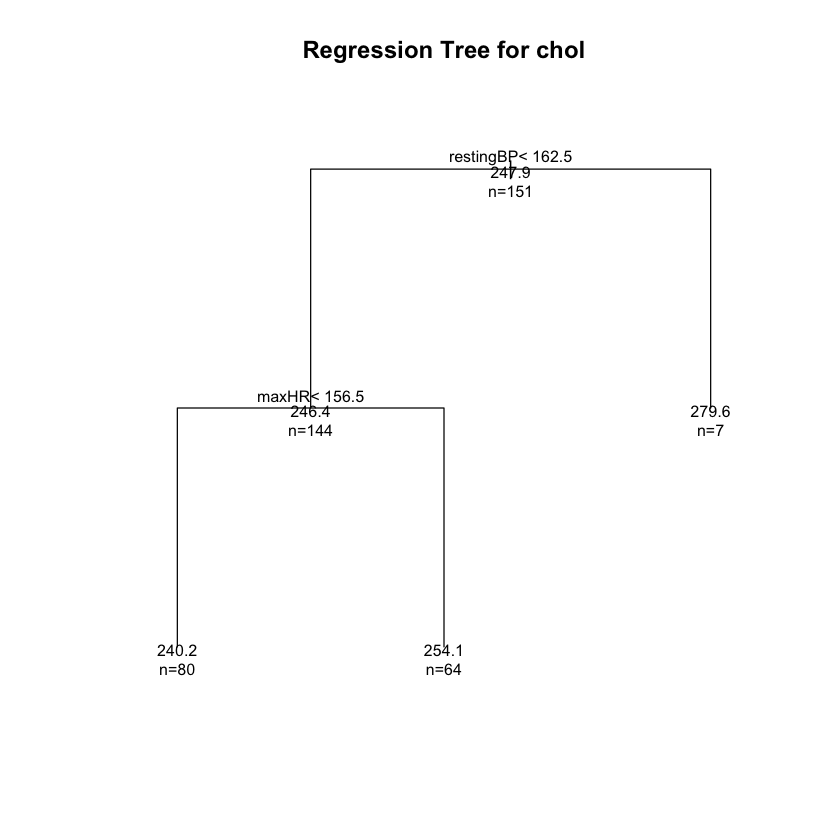

```r
library(rpart)
rt = rpart(Y2train ~., data=train2, method="anova", control=c(maxdepth=2))
options(repr.plot.width=7, repr.plot.height=7)
plot(rt, uniform=TRUE, main="Regression Tree for chol", margin=0.1)
text(rt, use.n=TRUE, all=TRUE, cex=.8)
```

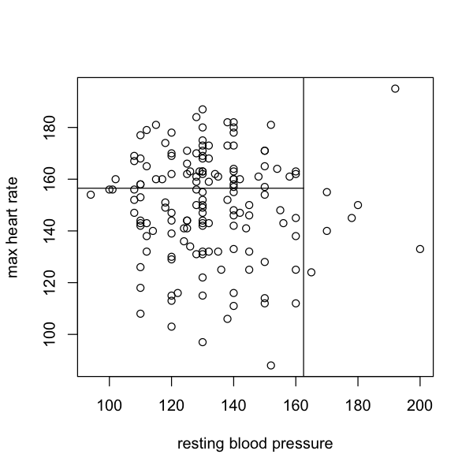

```r
options(repr.plot.width=5, repr.plot.height=5)
library(graphics)

plot(train2$restingBP, train2$maxHR, xlab="resting blood pressure", ylab="max heart rate")
abline(v=162.5)
segments(x0=162.5, y0=156.5, x1=90, y1=156.5)
```

Our predictor space is $\mathbb{R}^2$. (Technically not, since human heart rate and resting blood pressure have limited range)

- $R_1, R_2, R_3$ are known as **terminal nodes** or **leaves** of the tree
- Points where predictor space is split = **internal nodes**
- Segments of the tree connecting the nodes = **branches**

### How to fit a regression tree

1. Divide the predictor space into $J$ distinct and non-overlapping regions, $R_1, \ldots, R_J$.
   - Find high-dimensional rectangles ("boxes") that minimize the RSS: $$\sum_{j=1}^J \sum_{i \in R_j} (y_i - \widehat{y}_{R_j})^2$$
2. For every observation that falls into region $R_j$, we make the same prediction, which is the mean of response values for the training observations in $R_j$.

### Pruning the tree

- The previous process is likely to give a complex tree which overfits the data
- Solution: Grow a smaller tree, with fewer splits
- How to do this?
  - Only allow splits that yield high reduction in RSS
  - Grow a large tree $T_0$ and "prune" it back to a subtree.
- The second approach is preferable and is accomplished via **complexity pruning** and cross-validation.

The first regression tree was small because I wanted a simple example and so I restricted the tree depth to 2 (`maxdepth=2`).

If I don't restrict the depth, I get the following regression tree:

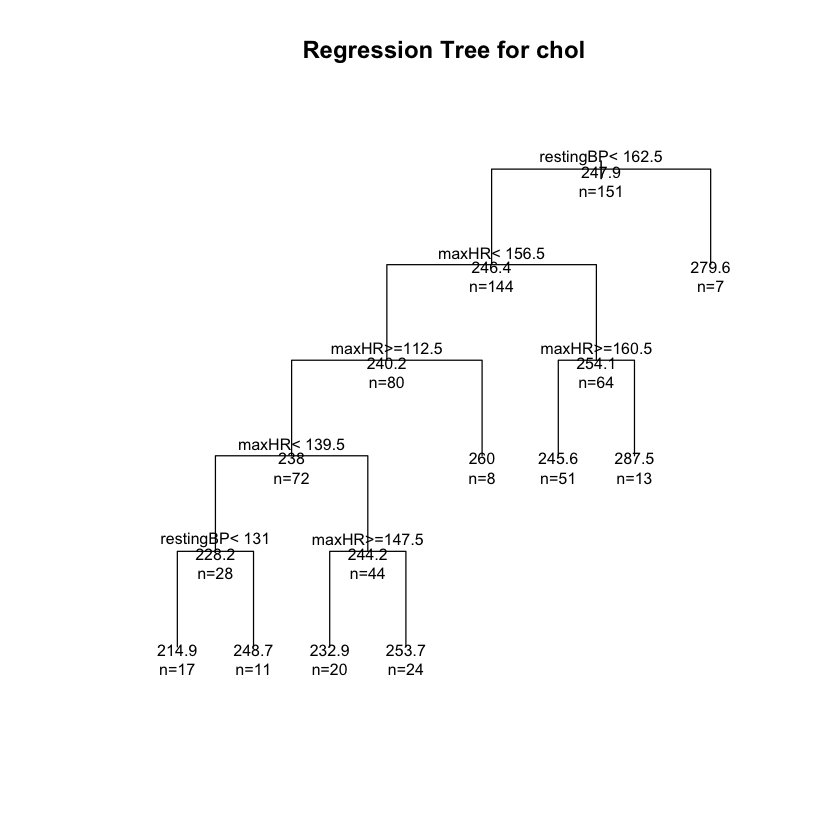

```r
rt = rpart(Y2train ~., data=train2, method="anova")
options(repr.plot.width=7, repr.plot.height=7)
plot(rt, uniform=TRUE, main="Regression Tree for chol", margin=0.1)
text(rt, use.n=TRUE, all=TRUE, cex=.8)
```

As you can see, it's fairly complex! You can check the fit like so:

```r
printcp(rt) # display the results
summary(fit) # detailed summary of splits
```

```
Regression tree:
rpart(formula = Y2train ~ ., data = train2, method = "anova")

Variables actually used in tree construction:
[1] maxHR     restingBP

Root node error: 405632/151 = 2686.3

n= 151

        CP nsplit rel error xerror    xstd
1 0.026588      0   1.00000 1.0146 0.26047
2 0.012741      3   0.92024 1.1577 0.26838
3 0.011645      6   0.88202 1.0898 0.22500
4 0.010000      7   0.87037 1.1117 0.22513
```

```
        Length Class  Mode
prior   2      -none- numeric
counts  2      -none- numeric
means   4      -none- numeric
scaling 2      -none- numeric
lev     2      -none- character
svd     1      -none- numeric
N       1      -none- numeric
call    3      -none- call
```

Now let's prune the tree:

```r
cp_cv = as.numeric(rt$cptable[which.min(rt$cptable[,"xerror"]),"CP"])
print(cp_cv)
```

```
[1] 0.02658768
```

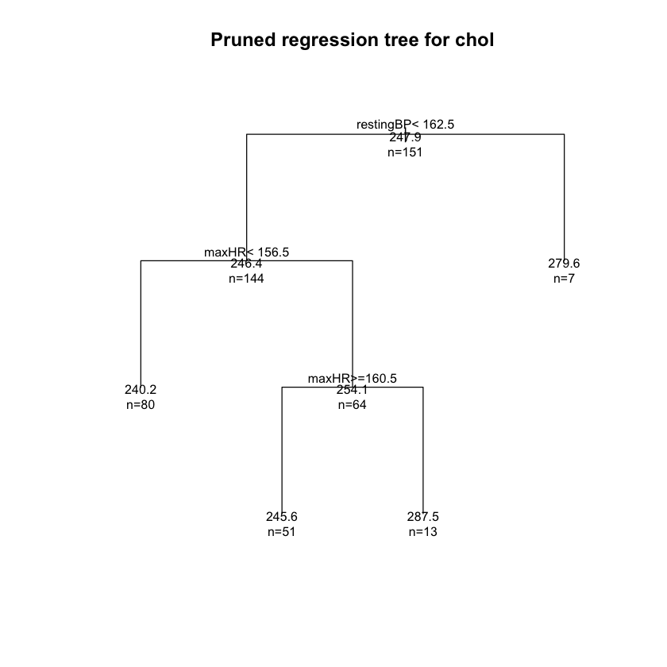

```r
prt = prune(rt, cp=0.02)
plot(prt, uniform=TRUE, main="Pruned regression tree for chol", margin=0.1)
text(prt, use.n=TRUE, all=TRUE, cex=.8)
```

## Classification trees

Now suppose we're trying to predict **whether a patient has heart disease** from two features their **cholesterol level** and their **max heart rate**.

Before the response was continuous, so we used a regression tree. Now the response is categorical, so we use a **classifiction tree**.

### How to "grow" a classification tree

- Very similar to growing a regression tree
- However, we can no longer use RSS as a criterion for making the binary splits! (Why?)
- Solution: use a "purity measure" as the splitting criterion
  1. Gini index
  2. Entropy

The code to fit a classification tree is nearly the same as the code we used to fit a regression tree, but we change `method="anova"` to `method="class"`.

Here I use the Gini index for splitting. I set `maxdepth=3` for simplicity, though you can prune classification trees just like regression trees.

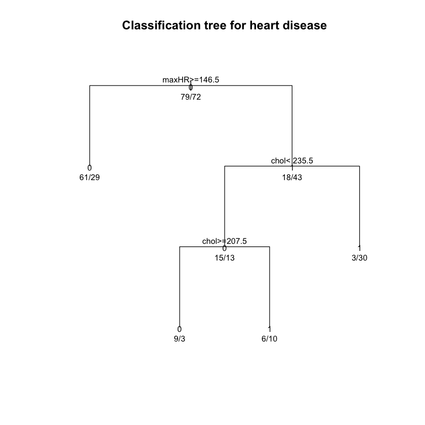

```r
ct = rpart(Ytrain ~., data=train, method="class", parms=list(split="gini") , control=c(maxdepth=3))
plot(ct, uniform=TRUE, main="Classification tree for heart disease", margin=0.1)
text(ct, use.n=TRUE, all=TRUE, cex=.8)
```

Trees have several advantages:

- Very interpretable
- Easy to visualize
- Can handle qualitative predictors easily (don't have to make "dummy variables")

Trees also have disadvantages:

- Don't generally have high predictive accuracy
- May not be **robust**

We can overcome the main disadvantage of trees by combining, or **bagging**, lots of trees.

**Random Forests** is basically bagged trees, but with a minor modification (that helps to further increase test accuracy).

## Random Forests in R

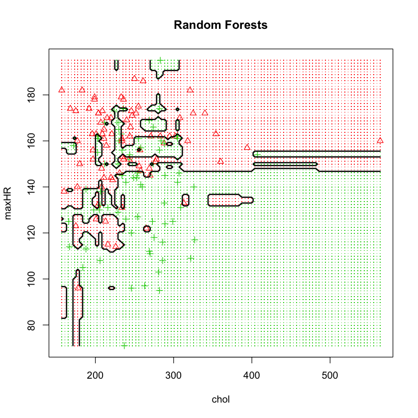

```r
library(randomForest)
model <- randomForest(Ytrain ~ ., data=train)
decisionplot(model, train, class = "Ytrain", main = "Random Forests")
```

# Questions for you

- We saw that nonlinear classifiers produce more flexible classification boundaries. Why might we still want to use a linear classifier over a nonlinear classifier?
- Today we didn't discuss the actual datasets you'll be working with. It turns out that some of these classifiers don't work well when applied to those datasets.
  - Which ones?
  - Can you think of some reasons why?

# Recap of R packages

|  |  | package |  | functions |  |
| --- | --- | --- | --- | --- | --- |
| kNN |  | `class` |  | `knn` |  |
| Logistic regression |  |  |  | `glm` |  |
| LDA |  | `MASS` |  | `lda` |  |
| QDA |  | `MASS` |  | `qda` |  |
| Random Forests |  | `randomForest` |  | `randomForest` |  |

- Questions about what a function's inputs and outputs are? Try `help(function_name_here)` in the R console or Jupyter notebook.

# Some helpful resources

**Random forest**

- https://www.statmethods.net/advstats/cart.html